# Un gráfico 3D en perspectiva

Christian Salas-Eljatib, Ph.D.

E-mail: cseljatib@gmail.com | Web: https://eljatib.com

Este código de R corresponde a la figura 6.11 del libro **Análisis de datos con el programa estadístico R: una introducción aplicada** de Salas-Eljatib (2021).

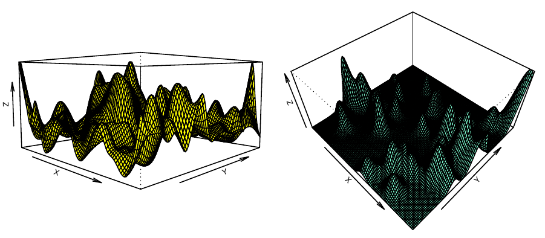

### Cargando los datos de ejemplo

Ocuparemos la dataframe **pspRuca** del paquete *datana* de Salas-Eljatib, Riquelme, and Pino (2021).

```r
library(datana)
data(pspRuca)
df <- pspRuca
head(df) #primeras seis filas
```

```
  tree.no           spp status    dbh x.coord y.coord crown.class
1       1    N. obliqua      1  65.50  2.7282 0.62986           1
2       2  A. punctatum      1  75.90  9.1970 4.30179           1
3       3  A. punctatum      1  44.10 17.1026 0.62677           1
4       4 E. cordifolia      1 135.75 20.0614 0.57813           1
5       5  A. punctatum      1  78.25  3.9795 2.20588           1
6       6    N. obliqua      1  91.80  5.1683 1.88111           1
```

```r
nrow(df) #numero de filas de la dataframe
```

```
[1] 716
```

Esta dataframe contiene la informacion de coordenadas cartesianas de arboles en una parcela de muestreo de 10.000 m$^2$ (1 hectárea) en un bosque adulto de Olivillo-Roble-Laurel-Ulmo en el predio Rucamanque (Depresion intermedia de la region de la Araucania, Chile). Los datos fueron recolectados por Salas et al. (2006).

## Los gráficos

En el libro se muestran dos gráficos sobre funciones de de densidad (o ``Kernel’’) para la distribucion espacial de árboles en un bosque nativo en Chile. La estimacion de densidad por funciones Kernel es una alternativa de modelacion en análisis espacial que toma en consideracion la posicion de elementos en relacion a otros Schabenberger and Gotway (2005).

Para realizar esta figura del libro es necesario tambien cargar los siguientes paquetes

```r
library(splancs)
library(spatstat)
```

Es recomendable tambien instalar el paquete **geoR** Ribeiro and Diggle (2001).

### El primer gráfico (el de la izquierda de la figura del libro)

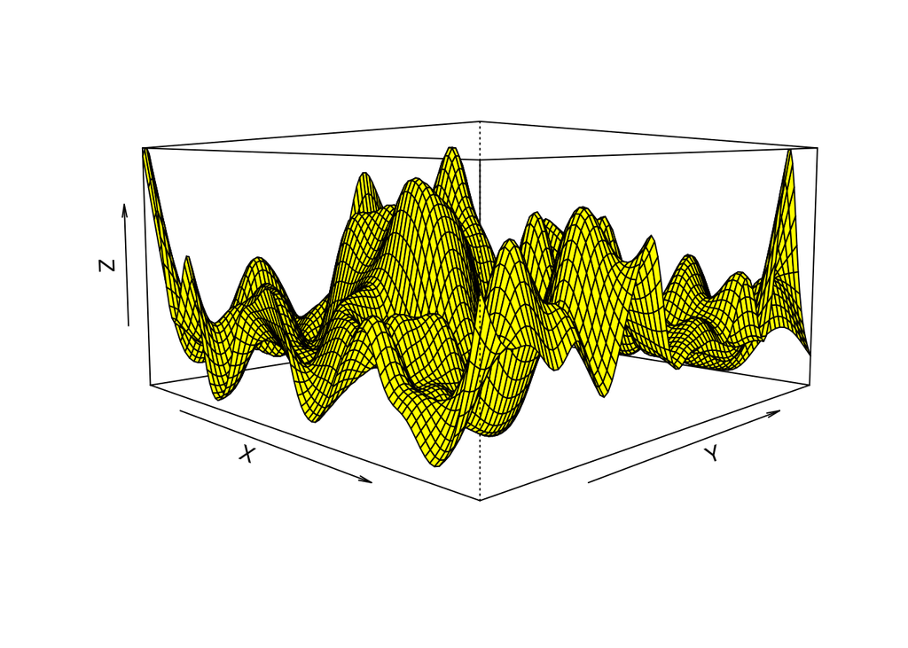

```r
range.x<-c(0,100);range.y<-c(0,100)
plot.area<-max(range.x)*max(range.y)

# grupo 1: arboles del dosel superior y vivos
db.g1 <- df[df[,"crown.class"]==1&df[,"status"]==1,]
db.g1.pts <- as.points(db.g1[,"x.coord"],db.g1[,"y.coord"])
db.g1.ppp <- ppp(db.g1.pts[,1],db.g1.pts[,2],xrange=range.x,yrange=range.x)
# ----------
#estimacion de la densidad kernel para grupo 1
dens.g1.sig2<-density.ppp(db.g1.ppp,sigma=3.5,dimyx=c(max(range.x),max(range.y)))

persp(dens.g1.sig2,theta=45,phi=5,xlab="X",ylab="Y",zlab="Z",cex.lab=1.5,main="", col="yellow")
```

### El segundo gráfico (el de la derecha de la figura del libro)

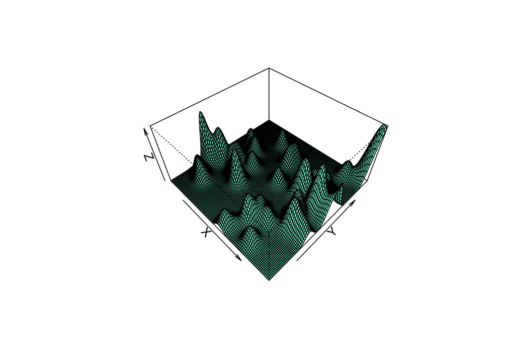

```r
# grupo 2: arboles del dosel inferior y muertos en pie
db.g2<-df[df[,"crown.class"]==3&df[,"status"]==2,]

db.g2.pts<-as.points(db.g2[,"x.coord"],db.g2[,"y.coord"]);
db.g2.ppp=ppp(db.g2.pts[,1],db.g2.pts[,2],xrange=range.x,yrange=range.x)
# ----------
#estimacion de la densidad kernel para grupo 2
dens.g2.sig2<-density.ppp(db.g2.ppp,sigma=3.5,dimyx=c(max(range.x),max(range.y)))


persp(dens.g2.sig2,theta=45,phi=45,xlab="X",ylab="Y",zlab="Z",cex.lab=1.5,main="",col="aquamarine")
```

### Comentarios/sugerencias?

Cualquier error que encuentre en este ejemplo, comentario o sugerencia, no dude en contactarme vía e-mail. Muchas gracias desde ya.

## Bibliografía

Ribeiro, P. J., Jr., and P. J. Diggle. 2001. “`geoR`: A Package for Geostatistical Analysis.” *R News* 1 (2): 14–18.

Salas, C., V. LeMay, P. Núñez, P. Pacheco, and A. Espinosa. 2006. “Spatial patterns in an old-growth *Nothofagus obliqua* forest in south-central Chile.” *For. Ecol. Manage.* 231 (1-3): 38–46. https://doi.org/10.1016/j.foreco.2006.04.037.

Salas-Eljatib, C. 2021. *Análisis de datos con el programa estadístico R: una introducción aplicada*. Santiago, Chile: Ediciones Universidad Mayor. https://tienda.zigzag.cl/9789566086109-analisis-de-datos-con-el-programa-estadistico-r.html.

Salas-Eljatib, C., J. Riquelme, and N. Pino. 2021. *`datana`: Data and functions to accompany Análisis de datos con el programa estadístico R: una introducción aplicada*. https://eljatib.com/rlibro/datana.pdf.

Schabenberger, O., and C. A. Gotway. 2005. *Statistical methods for spatial data analysis*. Boca Raton, FL, USA: Chapman & Hall/CRC.